# Weight Lifting Exercise - Course Project

Ramy Hashem

October 29, 2017

# Introduction

Wearable devices are popular for many people to quantify how much of a particular activity they do, but they rarely quantify how well they do it.

“Weight Lifting Exercise Dataset” (Velloso et al., 2013) [^1] uses data from accelerometers on the belt, forearm, arm, and dumbell of 6 participants. Participants were asked to perform barbell lifts correctly and incorrectly in 5 different ways.

We will use different machine learning models, to predict with the measured data and classify different activities, as follows:  
* Class A: Exactly according to the specication  
* Class B: Throwing the elbows to the front  
* Class C: The dumbbell only halfway  
* Class D: Lowering the dumbbell only halfway  
* Class E: Throwing the hips to the front

[figure not shown]

Data recording sensors which provide three-axes acceleration, gyroscope and magnetometer data. (Velloso et al., 2013)

# Exploring Data

## Downloading Data

First we start by downloading the dataset, then reading both training and testing sets.

```r
download.file(fileUrl_train, destfile = "pml_training.csv")
download.file(fileUrl_test, destfile = "pml_testing.csv")
fileUrl_train <- "https://d396qusza40orc.cloudfront.net/predmachlearn/pml-training.csv"
fileUrl_test <- "https://d396qusza40orc.cloudfront.net/predmachlearn/pml-testing.csv"
```

```r
training_main <- read.csv("pml_training.csv")
testing_main <- read.csv("pml_testing.csv")
```

## Data Exploration

```r
dim(training_main); dim(testing_main)
str(training_main)
```

The training dataset has **19622** rows X **160** columns.

The testing dataset has **20** rows X **160** columns.

### Plotting data

There is no specific pattern in the data.

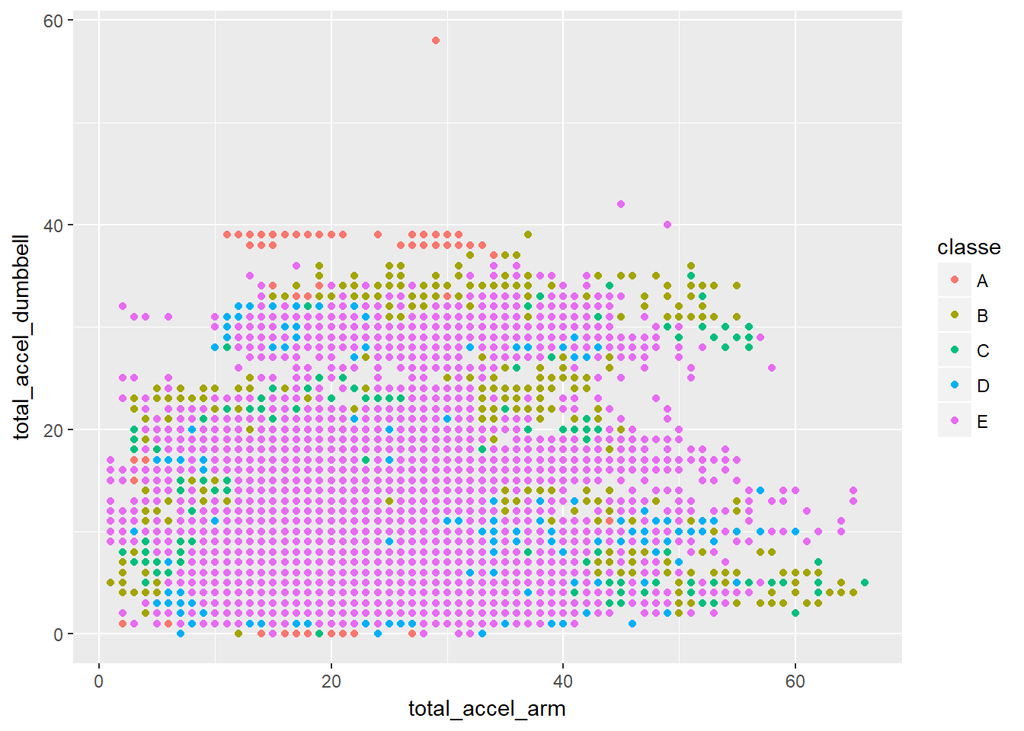

```r
library(ggplot2)
qplot(total_accel_arm, total_accel_dumbbell, data = training_main, color=classe)
```

## Data Preprocessing

The dataset has many data that are either NA or empty, in-order to fit a good model, we will exclude those variables.

```r
# Filter all columns that are not relevant. ie. has empty values or NA values
filter <- sapply(training_main, function(x) (sum(is.na(x)/dim(training_main)[1])>.9) | (sum(x == "")/dim(training_main)[1]>.9))

# Filter-out columns with missing data
training_main <- subset(training_main,select = !filter)
training_main <- subset(training_main, select = -c(1:7))
testing_main <- subset(testing_main,select = !filter)
testing_main <- subset(testing_main, select = -c(1:7))
```

The pre-processed training dataset has now **19622** rows X **53** variables

The pre-processed testing dataset hasnow **20** rows X **53** variables.

The variables that we will use in model fit are the following:

| Data | Data | Data | Data | Data | Data |
| --- | --- | --- | --- | --- | --- |
| roll_belt | accel_belt_z | gyros_arm_y | pitch_dumbbell | magnet_dumbbell_x | gyros_forearm_z |
| pitch_belt | magnet_belt_x | gyros_arm_z | yaw_dumbbell | magnet_dumbbell_y | accel_forearm_x |
| yaw_belt | magnet_belt_y | accel_arm_x | total_accel_dumbbell | magnet_dumbbell_z | accel_forearm_y |
| total_accel_belt | magnet_belt_z | accel_arm_y | gyros_dumbbell_x | roll_forearm | accel_forearm_z |
| gyros_belt_x | roll_arm | accel_arm_z | gyros_dumbbell_y | pitch_forearm | magnet_forearm_x |
| gyros_belt_y | pitch_arm | magnet_arm_x | gyros_dumbbell_z | yaw_forearm | magnet_forearm_y |
| gyros_belt_z | yaw_arm | magnet_arm_y | accel_dumbbell_x | total_accel_forearm | magnet_forearm_z |
| accel_belt_x | total_accel_arm | magnet_arm_z | accel_dumbbell_y | gyros_forearm_x | classe |
| accel_belt_y | gyros_arm_x | roll_dumbbell | accel_dumbbell_z | gyros_forearm_y |  |

## Data Partitioning

We create data partition for training and testing dataset. Whereby training will represent 70% of the dataset and 30% for the testing dataset.

```r
library(caret); library(randomForest)
set.seed(112233)

inTrain <- createDataPartition(training_main$classe, p=0.7, list=FALSE)
training <- training_main[inTrain,]
testing <- training_main[-inTrain,]
```

## Repeated K-Fold Cross-Validation

The dataset is quite large, and to train our model we will use K-Fold Cross-validation approach. With K-Folds of 10.

```r
# Train control with repeated K-fold Cross Validation

train_control <- trainControl(method="repeatedcv", number=10, repeats=3)
```

## Models

Given the massive size of the dataset, the processing time for the different models is lengthy. In this report we consider the trade-off between processing time Vs. Accuracy. Out of different models fits (**Q**uadratic **D**iscriminant **A**nalysis, **L**inear **D**iscriminant **A**nalysis, **G**eneralized **B**oosted **M**odels, **R**andom **F**orest), the QDA and Random Forest Models stood-out in processing time and accuracy.

```r
## Model fit gbm and lda
model_gbm <- train(classe~., data=training, trControl=train_control, method="gbm", verbose = FALSE)
model_lda <- train(classe~., data=training, trControl=train_control, method="lda")

## Total times used
model_gbm$times$final
model_lda$times$final

## Model Accuracy
gbm_accuracy <- confusionMatrix(training$classe, predict(model_gbm,training))$overall[1]
lda_accuracy <- confusionMatrix(training$classe, predict(model_lda,training))$overall[1]
```

|  | Accuracy | Processing Time |
| --- | --- | --- |
| GBM | 97.2% | 57 minutes |
| LDA | 70.4% | 3.8 seconds |

## Models used for prediction

The following 2 models are used for the final prediction:  
* QDA **Q**uadratic **D**iscriminant **A**nalysis  
* RF **R**andom **F**orest

```r
set.seed(11223344)

model_qda <- train(classe~., data=training, trControl=train_control, method="qda")

model_rf <- randomForest(classe~., data=training, importance=FALSE, ntree=512)
```

#### Model Accuracy and Confusion Matrix

```r
## QDA Model
model_qda
```

```
## Quadratic Discriminant Analysis
##
## 13737 samples
##    52 predictor
##     5 classes: 'A', 'B', 'C', 'D', 'E'
##
## No pre-processing
## Resampling: Cross-Validated (10 fold, repeated 3 times)
## Summary of sample sizes: 12364, 12363, 12364, 12363, 12363, 12362, ...
## Resampling results:
##
##   Accuracy   Kappa
##   0.8903452  0.8615367
```

```r
conf_qda <- confusionMatrix(training$classe, predict(model_qda,training))
model_qda$times
```

```
## $everything
##    user  system elapsed
##    9.39    1.41   10.94
##
## $final
##    user  system elapsed
##    0.15    0.02    0.17
##
## $prediction
## [1] NA NA NA
```

```r
conf_qda$overall[1]
```

```
##  Accuracy
## 0.8991046
```

```r
conf_qda$table
```

```
##           Reference
## Prediction    A    B    C    D    E
##          A 3613  159   79   49    6
##          B  135 2254  248    7   14
##          C    0  105 2274    9    8
##          D    4    8  294 1921   25
##          E    0   76  101   59 2289
```

```r
## Random Forest Model
model_rf
```

```
##
## Call:
##  randomForest(formula = classe ~ ., data = training, importance = FALSE,      ntree = 512)
##                Type of random forest: classification
##                      Number of trees: 512
## No. of variables tried at each split: 7
##
##         OOB estimate of  error rate: 0.56%
## Confusion matrix:
##      A    B    C    D    E class.error
## A 3902    3    0    0    1 0.001024066
## B    9 2645    4    0    0 0.004890895
## C    0   13 2380    3    0 0.006677796
## D    1    0   32 2216    3 0.015985790
## E    0    0    2    6 2517 0.003168317
```

#### Testing Dataset - Confusion Matrix for Random Forest

```r
# Random Forest Model Confusion Matrix on testing dataset
confusionMatrix(testing$classe, predict(model_rf,testing))
```

```
## Confusion Matrix and Statistics
##
##           Reference
## Prediction    A    B    C    D    E
##          A 1674    0    0    0    0
##          B    2 1136    1    0    0
##          C    0    6 1019    1    0
##          D    0    0   14  950    0
##          E    0    0    1    1 1080
##
## Overall Statistics
##
##                Accuracy : 0.9956
##                  95% CI : (0.9935, 0.9971)
##     No Information Rate : 0.2848
##     P-Value [Acc > NIR] : < 2.2e-16
##
##                   Kappa : 0.9944
##  Mcnemar's Test P-Value : NA
##
## Statistics by Class:
##
##                      Class: A Class: B Class: C Class: D Class: E
## Sensitivity            0.9988   0.9947   0.9845   0.9979   1.0000
## Specificity            1.0000   0.9994   0.9986   0.9972   0.9996
## Pos Pred Value         1.0000   0.9974   0.9932   0.9855   0.9982
## Neg Pred Value         0.9995   0.9987   0.9967   0.9996   1.0000
## Prevalence             0.2848   0.1941   0.1759   0.1618   0.1835
## Detection Rate         0.2845   0.1930   0.1732   0.1614   0.1835
## Detection Prevalence   0.2845   0.1935   0.1743   0.1638   0.1839
## Balanced Accuracy      0.9994   0.9971   0.9915   0.9975   0.9998
```

### Conclusion

The prediction model used with best accuracy to classify the exercise is *Random Forest* with ntree of 512. The prediction model is quite accurate with **99.6%**.

### References

[^1]: Velloso, E.; Bulling, A.; Gellersen, H.; Ugulino, W.; Fuks, H. Qualitative Activity Recognition of Weight Lifting Exercises. Proceedings of 4th International Conference in Cooperation with SIGCHI (Augmented Human ’13) . Stuttgart, Germany: ACM SIGCHI, 2013.